# Analysis of Ford GoBike System Data

## by Godwin Okemena

## Investigation Overview

The Aim of this investigation is to look at how the key features of Age and Trip duration in seconds influences individual rides made in a bike-sharing system covering the greater San Francisco Bay area.

## Dataset Overview

The data consisted of Trip duration in seconds and attributes of approximately 171,000 Trips. The attributes included Members birth year, gender, as well as additional variables such as user type whether customer or subscriber. About 3000 data points were removed from the analysis due to inconsistencies or missing information.

## Distribution of User's Age

The Ages in the dataset take on a range of values, from about 18 years at the lowest, to about 140 years at the highest. Plotted on a normal scale, the distribution of User Ages takes on a unimodal shape.

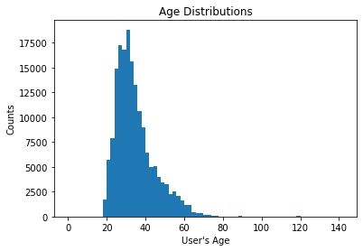

## Distribution of Trip Duration in seconds

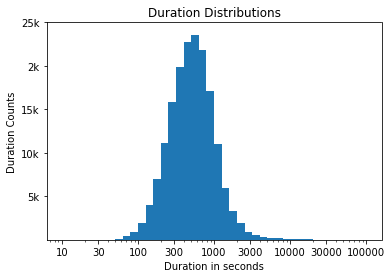

## Relationship Between Age and Trip Duration in seconds

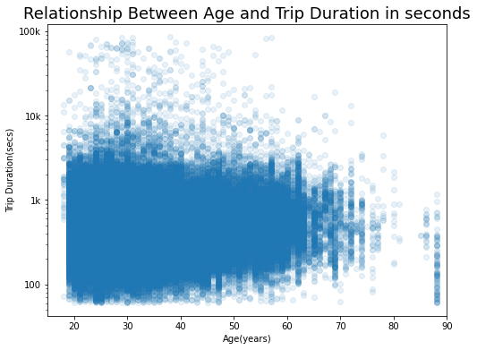

## Average Trip per User Type

The user type and average duration in seconds with Customer type having over 1300 average seconds duration in all trips and Subscriber have over 600 average duration in second. This implies that their casual users travel twice more than their clients in average duration of trips in seconds.

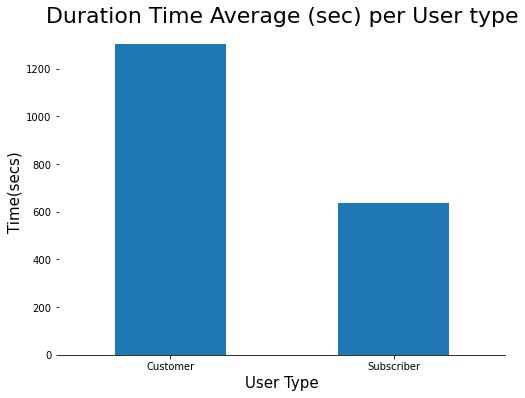

## A Relationship of Age, Gender and User Type

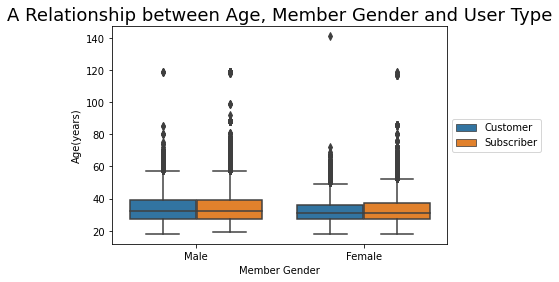